# Data Visualization Project 3: Major League Baseball Batting and Pitching Statistics for the 2015 Season

**Bryan Amaefule, Shannon Lu, Kevin Lee**

For our project we chose to analyze the batting and pitching statistic for Major League Baseball Players for the 2015 season. Data was taken from baseball-reference.com. The 2015 season is still in session, so statistics are only accurate up to October 15, 2015.

**Load require R packages**: As with all projects, it is first necessary to load the required packages into our R enviroment.

```r
require("tidyr")
require("dplyr")
require("jsonlite")
require("RCurl")
require("reshape2")
require("ggplot2")
```

**Reformat CSV files and load them into Oracle**: Using the code provided in the R_ELT file, we reformat each of the CSV files used in our project to suitable formats for insertion into the Oracle databases. The most important part of this step is making sure all numerical variables are properly formatted. We modify the measures vector to contain the titles of column with numerical values. We use the column names from the “baseball.csv” file as an example below.

```r
measures <- c("Rk","Age","G","PA","AB","R","H","doubles","triples","HR","RBI","SB","CS","BB","SO","BA",  "OBP","SLG","OPS","TB","GDP","HBP","SH","SF","IBB")
```

**Load data tables from Oracle database**: We load each the Oracle data tables into our environment using the code provided from the Titanic Analysis. We use four data sets including: batting statisitcs from 2015 season, batting statistics from 2014 season, team batting averages, pitching statistics from 2015 season.

```r
baseball <- data.frame(fromJSON(getURL(URLencode('129.152.144.84:5001/rest/native/?query="select * from baseball"'),httpheader=c(DB='jdbc:oracle:thin:@129.152.144.84:1521/PDBF15DV.usuniversi01134.oraclecloud.internal', USER='cs329e_ba7433', PASS='orcl_ba7433', MODE='native_mode', MODEL='model', returnDimensions = 'False', returnFor = 'JSON'), verbose = TRUE), ))

baseball2014 <- data.frame(fromJSON(getURL(URLencode('129.152.144.84:5001/rest/native/?query="select * from baseball2014"'),httpheader=c(DB='jdbc:oracle:thin:@129.152.144.84:1521/PDBF15DV.usuniversi01134.oraclecloud.internal', USER='cs329e_ba7433', PASS='orcl_ba7433', MODE='native_mode', MODEL='model', returnDimensions = 'False', returnFor = 'JSON'), verbose = TRUE), ))

baseball_teams <- data.frame(fromJSON(getURL(URLencode('129.152.144.84:5001/rest/native/?query="select * from baseball_teams"'),httpheader=c(DB='jdbc:oracle:thin:@129.152.144.84:1521/PDBF15DV.usuniversi01134.oraclecloud.internal', USER='cs329e_ba7433', PASS='orcl_ba7433', MODE='native_mode', MODEL='model', returnDimensions = 'False', returnFor = 'JSON'), verbose = TRUE), ))

baseball_pitching <- data.frame(fromJSON(getURL(URLencode('129.152.144.84:5001/rest/native/?query="select * from baseball_pitching"'),httpheader=c(DB='jdbc:oracle:thin:@129.152.144.84:1521/PDBF15DV.usuniversi01134.oraclecloud.internal', USER='cs329e_ba7433', PASS='orcl_ba7433', MODE='native_mode', MODEL='model', returnDimensions = 'False', returnFor = 'JSON'), verbose = TRUE), ))
```

Lets take a peak at what some of the data looks like.

```r
head(baseball)
```

```
##                 NAME  TM  LG    X  X_1  RK AGE   G  PA  AB  R   H DOUBLES
## 1   Nick Castellanos DET  AL null null 235  23 154 595 549 42 140      33
## 2    Rusney Castillo BOS  AL null null 236  27  80 289 273 35  69      10
## 3 Welington Castillo TOT MLB null null 237  28 110 378 342 42  81      15
## 4 Welington Castillo TOT  NL null null 238  28 104 350 317 39  77      15
## 5 Welington Castillo CHC  NL null null 239  28  24  47  43  5   7       2
## 6 Welington Castillo SEA  AL null null 240  28   6  28  25  3   4       0
##   TRIPLES HR RBI SB CS BB  SO                BA               OBP
## 1       6 15  73  0  3 39 152 0.254999995231628 0.303000003099442
## 2       2  5  29  4  5 13  54 0.252999991178513 0.287999987602234
## 3       1 19  57  0  0 25  92 0.237000003457069 0.296000003814697
## 4       1 19  55  0  0 24  87 0.243000000715256 0.305999994277954
## 5       0  2   5  0  0  3  12 0.163000002503395 0.233999997377396
## 6       0  0   2  0  0  1   5 0.159999996423721 0.179000005125999
##                 SLG               OPS  TB GDP HBP SH SF IBB
## 1 0.418999999761581 0.721000015735626 230  21   1  0  6   1
## 2 0.358999997377396 0.647000014781952  98  11   1  1  1   0
## 3 0.453000009059906              0.75 155  12   6  0  5   1
## 4 0.476000010967255 0.782000005245209 151  10   6  0  3   1
## 5 0.349000006914139 0.583000004291534  15   0   1  0  0   1
## 6 0.159999996423721  0.33899998664856   4   2   0  0  2   0
```

```r
head(baseball_teams)
```

```
##    TM NUMBAT BATAGE  RPG   G   PA   AB   R    H DOUBLES TRIPLES  HR RBI
## 1 ARI     50   26.6 4.44 162 6276 5649 720 1494     289      48 154 680
## 2 ATL     60   28.8 3.54 162 6034 5420 573 1361     251      18 100 548
## 3 BAL     48   27.9 4.40 162 6007 5485 713 1370     246      20 217 686
## 4 BOS     51   28.3 4.62 162 6237 5640 748 1496     294      33 161 706
## 5 CHC     50   26.9 4.25 162 6200 5491 689 1341     272      30 171 657
## 6 CHW     40   28.2 3.84 162 6070 5533 622 1381     260      27 136 595
##    SB CS  BB   SO    BA   OBP   SLG   OPS   TB GDP HBP SH SF IBB  LOB
## 1 132 44 490 1312 0.264 0.324 0.414 0.738 2341 134  33 46 57  40 1153
## 2  69 33 471 1107 0.251 0.314 0.359 0.674 1948 148  44 67 31  39 1145
## 3  44 25 418 1331 0.250 0.307 0.421 0.728 2307 127  51 20 32  23  990
## 4  71 27 478 1148 0.265 0.325 0.415 0.740 2339 127  46 30 42  28 1142
## 5  95 37 567 1518 0.244 0.321 0.398 0.719 2186 101  74 32 35  47 1165
## 6  68 42 404 1231 0.250 0.306 0.380 0.686 2103 125  65 30 37  22 1065
```

```r
head(baseball_pitching)
```

```
##                NAME  TM LG RK AGE W L                WL              ERA
## 1   Andrew Bellatti TBR AL 59  23 3 1              0.75 2.30999994277954
## 2    Joaquin Benoit SDP NL 60  37 6 5 0.545000016689301 2.33999991416931
## 3 Christian Bergman COL NL 61  27 3 1              0.75 4.73999977111816
## 4   Dellin Betances NYY AL 62  27 6 4 0.600000023841858              1.5
## 5 Rafael Betancourt COL NL 63  40 2 4 0.333000004291534 6.17999982833862
## 6       Chad Bettis COL NL 64  26 8 6 0.570999979972839 4.23000001907349
##    G GS GF CG SHO SV               IP   H  R ER HR BB IBB  SO HBP BK WP
## 1 17  0  6  0   0  0 23.1000003814697  16  7  6  4 10   0  18   1  0  0
## 2 67  0 11  0   0  2 65.0999984741211  36 17 17  7 23   1  63   2  0  2
## 3 30  4  6  0   0  0 68.0999984741211  82 36 36  8 15   1  37   0  0  4
## 4 74  0 17  0   0  9               84  45 17 14  6 40   2 131   3  0  9
## 5 45  0  9  0   0  1 39.0999984741211  43 29 27  4 12   4  40   0  0  0
## 6 20 20  0  0   0  0              115 120 56 54 11 42   2  98   3  0  6
##    BF ERAPLUS              FIP              WHIP            HNINE
## 1  95     173 5.23000001907349   1.1139999628067 6.19999980926514
## 2 254     156             3.75 0.902999997138977                5
## 3 286      99 4.23000001907349  1.41999995708466 10.8000001907349
## 4 332     266 2.48000001907349  1.01199996471405 4.80000019073486
## 5 175      76 3.33999991416931  1.39800000190735 9.80000019073486
## 6 502     110 3.84999990463257  1.40900003910065 9.39999961853027
##              HRNINE           BBNINE           SONINE              SOW
## 1               1.5 3.90000009536743 6.90000009536743 1.79999995231628
## 2                 1 3.20000004768372 8.69999980926514 2.74000000953674
## 3  1.10000002384186                2 4.90000009536743 2.47000002861023
## 4 0.600000023841858 4.30000019073486               14 3.27999997138977
## 5 0.899999976158142 2.70000004768372 9.19999980926514 3.32999992370605
## 6 0.899999976158142 3.29999995231628 7.69999980926514 2.32999992370605
```

```r
summary(baseball)
```

```
##                  NAME            TM          LG         X
##  Name              :  64   TOT    : 135   AL  :771   null:1685
##  Alejandro De Aza* :   5   Tm     :  64   Lg  : 64
##  Mat Latos         :   5   ATL    :  60   MLB : 74
##  Welington Castillo:   5   TEX    :  57   NL  :775
##  David Carpenter   :   4   NYY    :  56   null:  1
##  Jose Ramirez      :   4   LAD    :  55
##  (Other)           :1598   (Other):1258
##    X_1             RK            AGE            G              PA
##  null:1685   null   :  65   27     :196   null   :  64   0      :491
##              1      :   1   25     :162   2      :  39   1      : 80
##              10     :   1   26     :150   1      :  38   null   : 64
##              100    :   1   28     :149   5      :  34   2      : 55
##              1000   :   1   24     :136   6      :  34   3      : 44
##              1001   :   1   29     :136   11     :  33   4      : 29
##              (Other):1615   (Other):756   (Other):1443   (Other):922
##        AB            R             H          DOUBLES       TRIPLES
##  0      :379   0      :658   0      :585   0      :763   0      :1104
##  null   :188   null   :188   null   :188   2      :127   1      : 161
##  1      : 80   1      :103   1      : 85   null   :124   null   : 124
##  2      : 62   2      : 54   2      : 59   1      :108   3      : 118
##  3      : 36   6      : 38   3      : 34   3      : 42   2      :  85
##  4      : 26   3      : 35   4      : 26   4      : 35   4      :  27
##  (Other):914   (Other):609   (Other):708   (Other):486   (Other):  66
##        HR           RBI            SB             CS             BB
##  0      :892   0      :706   0      :1054   0      :1092   0      :711
##  null   :188   null   :188   null   : 188   null   : 188   null   :188
##  1      : 96   1      : 78   1      :  98   1      : 159   1      : 96
##  2      : 61   3      : 45   2      :  91   2      :  87   2      : 54
##  5      : 50   2      : 44   3      :  53   3      :  44   3      : 41
##  4      : 46   4      : 36   4      :  32   4      :  33   4      : 35
##  (Other):352   (Other):588   (Other): 169   (Other):  82   (Other):560
##        SO                      BA                     OBP
##  0      :459   null             :567   null             :562
##  null   :188   0                :206   0                :188
##  1      :103   0.25             : 28   0.333000004291534: 32
##  2      : 59   0.333000004291534: 20   0.25             : 31
##  3      : 41   0.166999995708466: 16   0.5              : 18
##  4      : 29   0.5              : 16   0.14300000667572 : 13
##  (Other):806   (Other)          :832   (Other)          :841
##                 SLG                     OPS            TB
##  null             :567   null             :567   0      :585
##  0                :206   0                :188   null   :188
##  0.5              : 25   0.666999995708466: 15   1      : 63
##  0.333000004291534: 24   1                : 15   2      : 49
##  0.25             : 15   0.5              : 12   3      : 34
##  0.200000002980232: 13   0.688000023365021:  9   4      : 34
##  (Other)          :835   (Other)          :879   (Other):732
##       GDP           HBP            SH             SF            IBB
##  0      :839   0      :997   0      :1023   0      :1031   0      :1158
##  null   :188   null   :188   1      : 188   null   : 188   null   : 188
##  1      :137   1      :151   null   : 188   1      : 151   1      : 149
##  2      : 86   2      :109   2      :  92   2      :  97   2      :  65
##  4      : 54   3      : 60   3      :  64   3      :  81   3      :  32
##  3      : 50   4      : 52   4      :  43   4      :  47   4      :  24
##  (Other):331   (Other):128   (Other):  87   (Other):  90   (Other):  69
```

The join functions of the dplyr package allow us to produce some intersting visualization from two datasets at time.

The first function we use is the anti join function. The anti join returns only rows from one table that are not found in the other. By using an anti join between the 2015 batting statistics and the 2014 batting statistics, we were effectivley able to obtain a data set containing only rookie MLB players.

```r
newbies <- dplyr::anti_join(baseball, baseball2014, by="NAME") %>% tbl_df
```

In order to visualize just how these rookies contribute to their teams, we plot their runs batted in (RBIs) grouped by team. RBI is a statistc that credits batters a batter for making a play that allows a run to be scored. You won’t see many feel-good baseball movies end on an RBI, but this is the principle method of scoring in baseball, as opposed to grand slams, home runs, and balls knocked out of the park.

We our visualizations into two plots separated by league just so the plot isnt too crowded. First we show rookies in the American League.

```r
source("../02 Data Wrangling/AL_Rookie_RBIs.R", echo=TRUE)
```

```
##
## > require(tidyr)
##
## > require(dplyr)
##
## > require("jsonlite")
##
## > require("RCurl")
##
## > require("reshape2")
##
## > require("ggplot2")
##
## > rookieAL <- newbies %>% select(TM, NAME, RBI, LG) %>%
## +     filter(LG == "AL")
##
## > ggplot() + coord_cartesian() + scale_x_discrete() +
## +     scale_y_continuous() + labs(title = "American League Rookie RBIs by Team") +
## +     labs( .... [TRUNCATED]
```

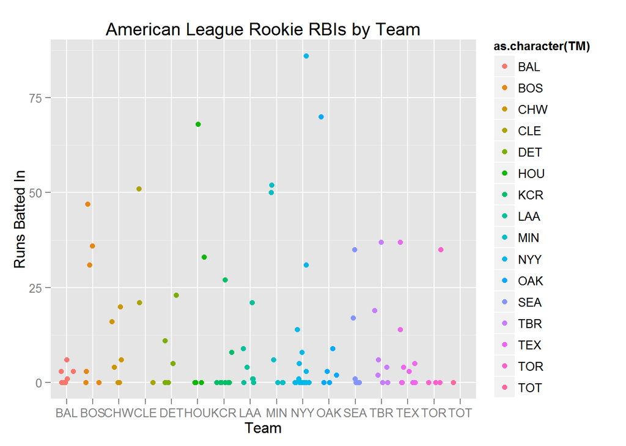

Then we show National League rookies.

```r
source("../02 Data Wrangling/NL_Rookie_RBIs.R", echo=TRUE)
```

```
##
## > require(tidyr)
##
## > require(dplyr)
##
## > require("jsonlite")
##
## > require("RCurl")
##
## > require("reshape2")
##
## > require("ggplot2")
##
## > rookieNL <- newbies %>% select(TM, NAME, RBI, LG) %>%
## +     filter(LG == "NL")
##
## > ggplot() + coord_cartesian() + scale_x_discrete() +
## +     scale_y_continuous() + labs(title = "National League Rookie RBIs by Team") +
## +     labs( .... [TRUNCATED]
```

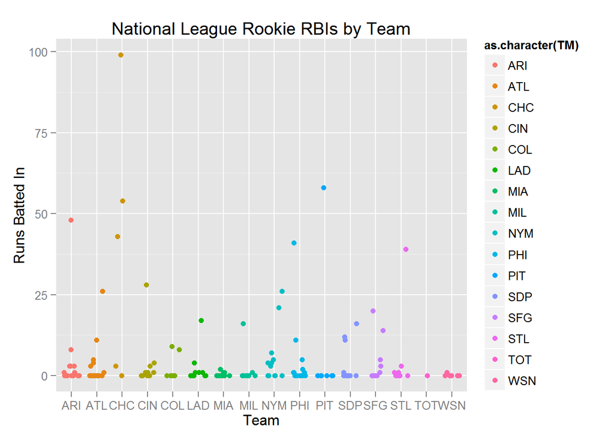

We see that a good portion of the rookies have already put some numbers on the board. Looking at the National League rookies, Kris Bryant of the Chicago Cubs stands out amongst all the rest with an impressive 99 runs batted in.

Our first anti join function gave us rough data set of all the rookies. By reversing that anti join, we should be able obtain a data set of players who retired this, or for some other reason, have sat this season out.

```r
retirees <- dplyr::anti_join(baseball2014, baseball, by="NAME") %>% tbl_df
```

Logically, we would expect this data set to be full of a bunch of washed up old guys. once again we separate into two visualizations grouped by league.

```r
source("../02 Data Wrangling/washedAL.R", echo=TRUE)
```

```
##
## > washedAL <- retirees %>% select(TM, NAME, RBI, LG,
## +     AGE) %>% filter(LG == "AL")
##
## > ggplot() + coord_cartesian() + scale_x_discrete() +
## +     scale_y_continuous() + labs(title = "American League Retiree Age by Team") +
## +     labs( .... [TRUNCATED]
```

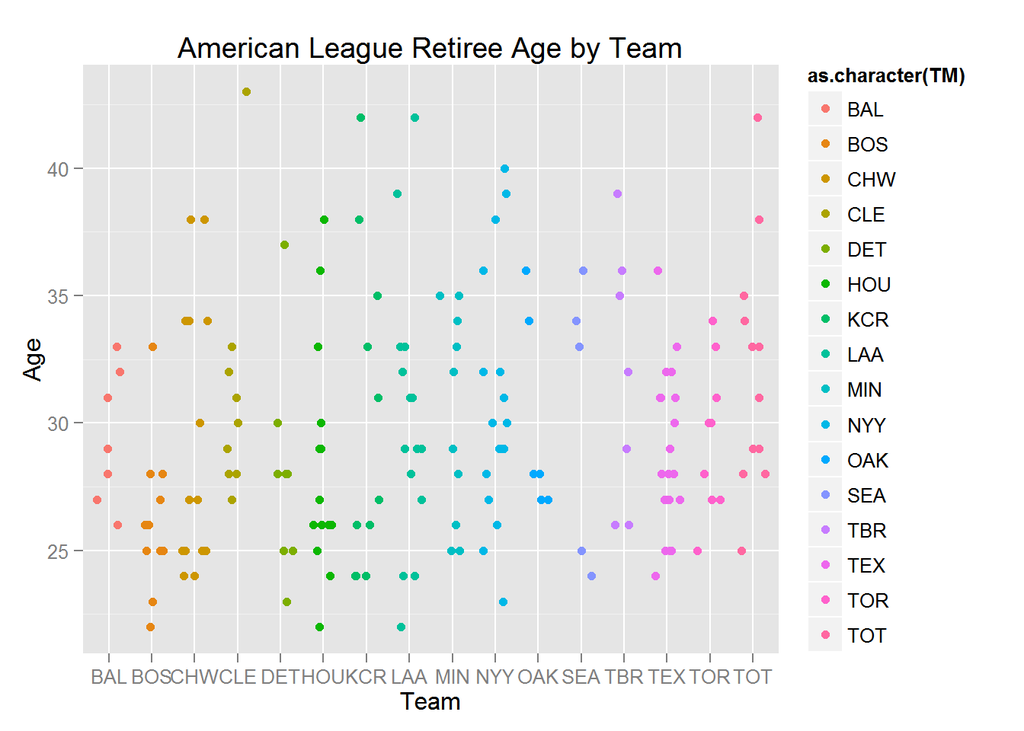

```r
source("../02 Data Wrangling/washedNL.R", echo=TRUE)
```

```
##
## > washedNL <- retirees %>% select(TM, NAME, RBI, LG,
## +     AGE) %>% filter(LG == "NL")
##
## > ggplot() + coord_cartesian() + scale_x_discrete() +
## +     scale_y_continuous() + labs(title = "National League Retiree Age by Team") +
## +     labs( .... [TRUNCATED]
```

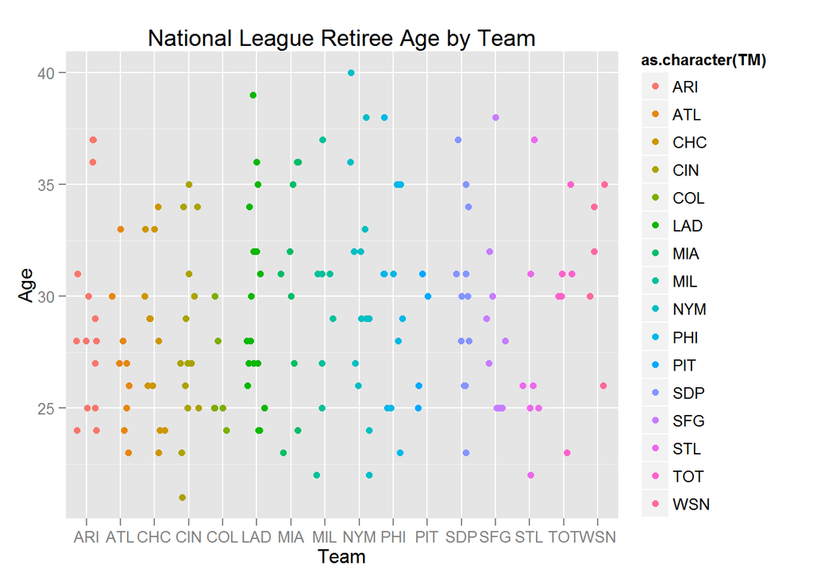

To our surpirse, we see that ages are all over the place. This shows that more factors than age that force players into retirement or missed season. Players could be out due to injuries, suspensions, or maybe they just were good enough to cut it in the major league. Such is the cruel world that is professional sports.

In 1973, the American League adopted the “Designated Hitter Rule” which allowed teams to appoint one player, the designated hitter, to bat in place of the teams pitcher. This substitution helps pitchers avoid injuries that could happen while at bat and simultaneously saves us fans from having to watch these God-awful pitchers struggle to get a hit. Fortunately, or unfortunately depending on who you ask, the National League has yet to adopt this rule leading to an asymmetry in the offense between the two leagues. We want to visualize just how often American League pitchers are opting out of batting compared to their National League counterparts.

None of the data sets we acquired show both batting and pitch statistics together, however, using an inner join, we can create such a data set ourselves. The inner join returns only rows found in both data sets, so by joining the batting and pitching statistics by player name we obtain a data set that includes the batting numbers for each pitcher.

```r
pitchers <- dplyr::inner_join(baseball, baseball_pitching, by="NAME") %>% tbl_df
```

By plotting the “At Bats” for each pitcher and grouping them by league, we can see just how often pitchers from each league are stepping up to the plate. We’d expect many of the American League pitchers to have zero at bats if they are choosing to let their designated hitters bat for them.

```r
source("../02 Data Wrangling/pitcher_at_bats.R", echo=TRUE)
```

```
##
## > require(tidyr)
##
## > require(dplyr)
##
## > require("jsonlite")
##
## > require("RCurl")
##
## > require("reshape2")
##
## > require("ggplot2")
##
## > pitchersAB <- pitchers %>% select(TM.x, NAME, RBI,
## +     AB, ERA, LG.x) %>% filter(LG.x != "MLB")
##
## > ggplot() + coord_cartesian() + scale_x_discrete() +
## +     scale_y_continuous() + labs(title = "National League and American League Pitchers At Bats ..." ... [TRUNCATED]
```

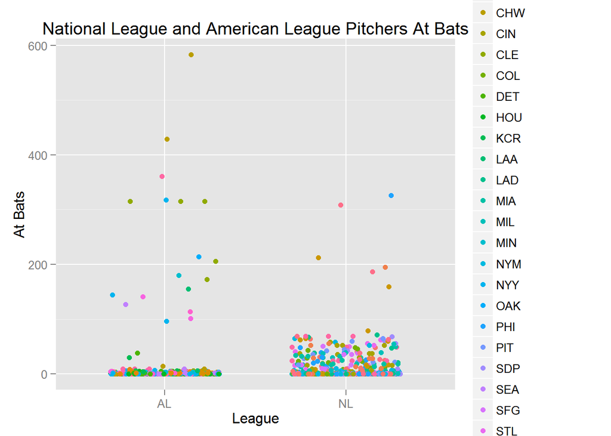

Just as we expected, there are a lot more pitchers with zero at bats in the American League as compared to the National League due the Designated Hitter Rule. The rule has been a polarizing topic of discussion in baseball for some time now, with many different factions debating how to standardize the two leagues or if standardization is even necessary.

Baseball is very much a team sport, especiialy on the offense. Unlike basketball, where a player (read: God) like Lebron James or Kevin Durant can score half of their team’s points on their own if need be, baseball relies on a batting order that mandates every player get the same number of at bats. This makes it difficult for any single baseball player to “put the team on their back”. To get a glimpse of just how much a load some of these players carry for their team, we use a full(or outer) join to compare each players batting statistics to the total batting numbers of their team.

```r
joinbyteam <- dplyr::full_join(baseball, baseball_teams, by="TM") %>% tbl_df
```

Using some crafty data wrangling a la the mutate function, we create another column in the data set showing just what percentage of the teams runs each player batted in. We arrange the data set by descending percentage to see which players put on the most for their team.

```r
source("../02 Data Wrangling/team_on_back.R", echo=TRUE)
```

```
##
## > teamOnBack <- joinbyteam %>% select(TM, NAME, RBI.x,
## +     R.y, LG) %>% filter(TM != "TOT") %>% mutate(freq = (as.numeric(as.character(RBI.x))/R.y) .... [TRUNCATED]
##
## > head(teamOnBack)
## Source: local data frame [6 x 6]
##
##    TM             NAME RBI.x R.y LG     freq
## 1 COL    Nolan Arenado   130 737 NL 17.63908
## 2 BAL     Chris Davis*   117 713 AL 16.40954
## 3 CHW       Jose Abreu   101 622 AL 16.23794
## 4 SDP        Matt Kemp   100 650 NL 15.38462
## 5 ARI Paul Goldschmidt   110 720 NL 15.27778
## 6 DET    J.D. Martinez   102 689 AL 14.80406
```

We see that Nolan Arenado of the Colorado Rockies has batted in a higher percentage of his teams runs than anyone else in the major leagues at 17.64%.

Which teams really relied on their stars for runs? Which teams split the load amongst their roster? To answer these questions we plot the percentage of runs scored by each player and group them by team, separating American League teams and National League teams into different plots.

```r
source("../02 Data Wrangling/teamOnBackAL.R", echo=TRUE)
```

```
##
## > teamOnBackAL <- teamOnBack %>% filter(LG == "AL")
##
## > ggplot() + coord_cartesian() + scale_x_discrete() +
## +     scale_y_continuous() + labs(title = "Player Run Percentage By Team (American League)") +  .... [TRUNCATED]
```

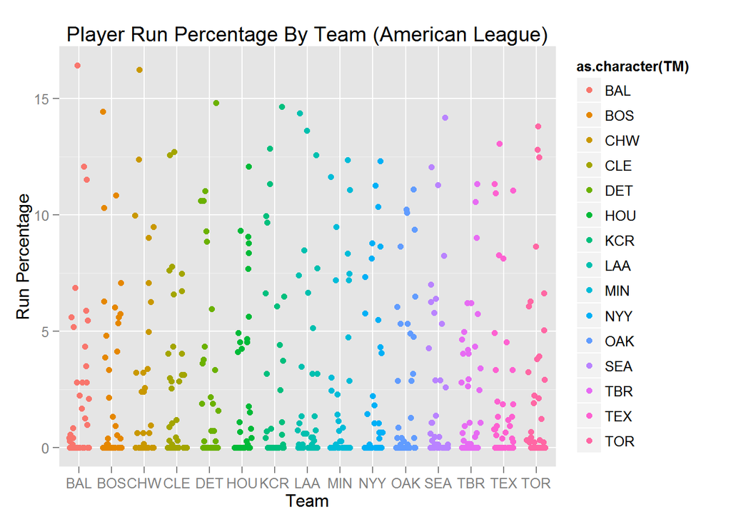

```r
source("../02 Data Wrangling/teamOnBackNL.R", echo=TRUE)
```

```
##
## > teamOnBackNL <- teamOnBack %>% filter(LG == "NL")
##
## > ggplot() + coord_cartesian() + scale_x_discrete() +
## +     scale_y_continuous() + labs(title = "Player Run Percentage By Team (National League)") +  .... [TRUNCATED]
```

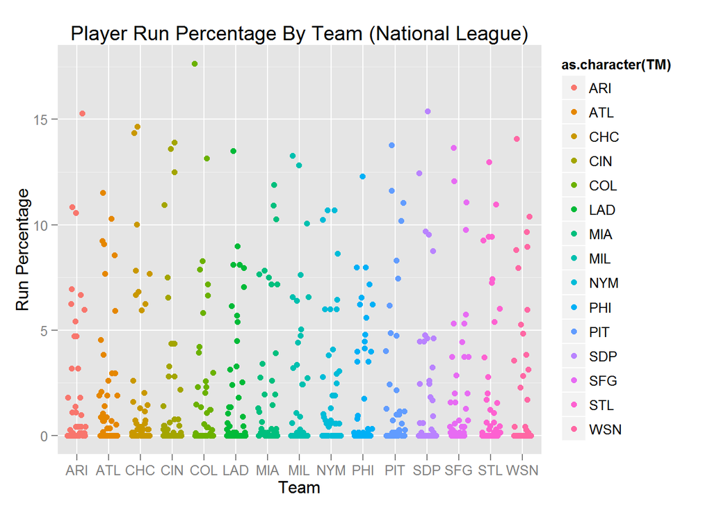

In the American League we see a decent number of teams relying on select players for a large amount of their runs, while in the National League we see team like the New York Mets and Philadelphia Phillies where the scoring is distributed a bit more evenly than other teams.